# Rafael_Carvalho_LogRegression_Project

```python
#Remove dependent variable and unwanted information

Valids = bank_model.drop(['Education_Undergrad','Securities Account_No','CD Account_No','Online_No','CreditCard_No'], axis=1)

X = bank_model.drop(['Personal Loan','Education_Undergrad','Securities Account_No','CD Account_No','Online_No','CreditCard_No'], axis=1)

Y = bank_model['Personal Loan']
```

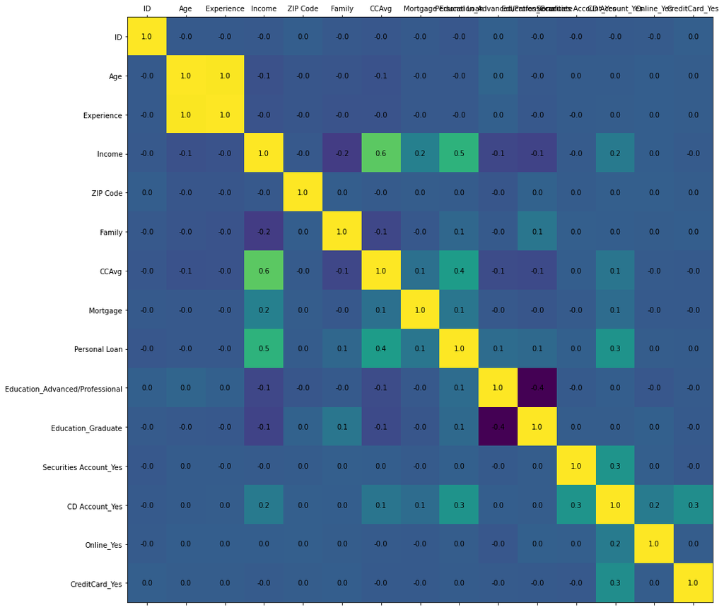

```python
# CORRELATION BETWEEN VARIABLES
def plot_correlation(Valids):
    corr = Valids.corr()
    fig, ax = plt.subplots(figsize=(15, 20))
    ax.matshow(corr)
    plt.xticks(range(len(corr.columns)), corr.columns)
    plt.yticks(range(len(corr.columns)), corr.columns)
    for (i, j), z in np.ndenumerate(corr):
        ax.text(j, i, '{:0.1f}'.format(z), ha='center', va='center')

plot_correlation(Valids)
```

3) - Split the data into training and test set in the ratio of 70:30 respectively

```python
# Split X and y into training and test set in 70:30 ratio

X_train, X_test, Y_train, Y_test = train_test_split(X, Y, test_size=0.30, random_state=1)
```

```python
print("\nCHECK Datasets size")
print("dataset:", len(bank_model),"rows")
print("X_train:", len(X_train),"rows")
print("X_test: ", len(X_test),"rows")
print("Y_train:", len(Y_train),"rows")
print("Y_test: ", len(Y_test),"rows")

print("\nCheck 70/30 Ratio")
print( "X train is:" ,round(len(X_train) / (len(X_train)+len(X_test))*100,1),"% of total dataset")
print( "X test  is:" ,round(len(X_test) / (len(X_train)+len(X_test))*100,1),"% of total dataset")
print( "Y train is:" ,round(len(Y_train) / (len(Y_train)+len(Y_test))*100,1),"% of total dataset")
print( "Y test  is:" ,round(len(Y_test) / (len(Y_train)+len(Y_test))*100,1),"% of total dataset")

print("\nCheck shapes")
print("dataset:", (bank_model.shape))
print("X_train:", (X_train.shape))
print("X_test: ", (X_test.shape))
print("Y_train:", (Y_train.shape))
print("Y_test: ", (Y_test.shape))
```

```
CHECK Datasets size
dataset: 4948 rows
X_train: 3463 rows
X_test:  1485 rows
Y_train: 3463 rows
Y_test:  1485 rows

Check 70/30 Ratio
X train is: 70.0 % of total dataset
X test  is: 30.0 % of total dataset
Y train is: 70.0 % of total dataset
Y test  is: 30.0 % of total dataset

Check shapes
dataset: (4948, 20)
X_train: (3463, 14)
X_test:  (1485, 14)
Y_train: (3463,)
Y_test:  (1485,)
```

4) - Use Logistic Regression model to predict whether the customer will take personal loan or not. Print all the metrics related for evaluating the model performance

Fit Logistic Regression Model

```python
# Fit the model on train using sklearn
model = LogisticRegression(solver="liblinear")
model.fit(X_train, Y_train)
#predict on test
Y_predict = model.predict(X_test)

coef_df = pd.DataFrame(model.coef_)
coef_df['intercept'] = model.intercept_
print(coef_df)
```

```
      0    1    2    3     4    5    6    7    8    9   10   11    12    13  \
0 -0.00 0.01 0.01 0.04 -0.00 0.02 0.01 0.00 0.01 0.01 0.00 0.00 -0.00 -0.00

   intercept
0      -0.00
```

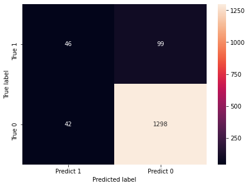

```python
cm=metrics.confusion_matrix(Y_test, Y_predict, labels=[1, 0])

df_cm = pd.DataFrame(cm, index = [i for i in ["True 1","True 0"]],
                  columns = [i for i in ["Predict 1","Predict 0"]])

plt.figure(figsize = (7,5))
sns.heatmap(df_cm, annot=True,fmt='.0f')
plt.ylabel('True label')
plt.xlabel('Predicted label')
```

```python
## function to get confusion matrix in a proper format
def draw_cm( actual, predicted ):
    cm = confusion_matrix( actual, predicted)
    sns.heatmap(cm, annot=True,  fmt='.2f', xticklabels = [0,1] , yticklabels = [0,1] )
    plt.ylabel('Observed')
    plt.xlabel('Predicted')
    plt.show()

print("\nTrainig accuracy",round(model.score(X_train,Y_train),3))

print("\nTesting accuracy",round(model.score(X_test, Y_test),3))


print("\nRecall:",round(recall_score(Y_test,Y_predict),2))

print("\nPrecision:",round(precision_score(Y_test,Y_predict),2))

print("\nF1 Score:",round(f1_score(Y_test,Y_predict),2))

print("\nRoc Auc Score:",round(roc_auc_score(Y_test,Y_predict),2))
```

```
Trainig accuracy 0.908

Testing accuracy 0.905

Recall: 0.32

Precision: 0.52

F1 Score: 0.39

Roc Auc Score: 0.64
```

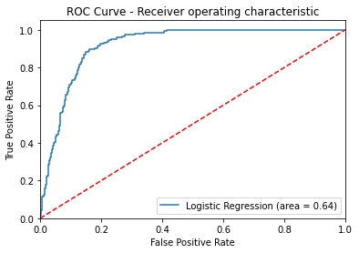

```python
#AUC ROC curve Analysis

logit_roc_auc = roc_auc_score(Y_test, model.predict(X_test))
fpr, tpr, thresholds = roc_curve(Y_test, model.predict_proba(X_test)[:,1])
plt.figure()
plt.plot(fpr, tpr, label='Logistic Regression (area = %0.2f)' % logit_roc_auc)
plt.plot([0, 1], [0, 1],'r--')
plt.xlim([0.0, 1.0])
plt.ylim([0.0, 1.05])
plt.xlabel('False Positive Rate')
plt.ylabel('True Positive Rate')
plt.title('ROC Curve - Receiver operating characteristic')
plt.legend(loc="lower right")
plt.show()
```

```python
# Running a loop to check different values of 'solver'
# all solver can be used with l2, only 'liblinear' and 'saga' works with both 'l1' and 'l2'

train_score=[]
test_score=[]
solver = ['newton-cg','lbfgs','liblinear','sag','saga']
for i in solver:
    model = LogisticRegression(random_state=42,penalty='l2', C = 0.75,solver=i)  # changing values of solver
    model.fit(X_train, Y_train)
    Y_predict = model.predict(X_test)
    train_score.append(round(model.score(X_train, Y_train),3))
    test_score.append(round(model.score(X_test, Y_test),3))

print(solver)
print()
print(train_score)
print()
print(test_score)
```

```
['newton-cg', 'lbfgs', 'liblinear', 'sag', 'saga']

[0.956, 0.908, 0.908, 0.903, 0.903]

[0.954, 0.905, 0.905, 0.902, 0.902]
```

```python
train_score=[]
test_score=[]
solver = ['liblinear','saga']   # changing values of solver which works with 'l1'
for i in solver:
    model = LogisticRegression(random_state=42,penalty='l1', C = 0.75,solver=i)  #changed penalty to 'l1'
    model.fit(X_train, Y_train)
    Y_predict = model.predict(X_test)
    train_score.append(round(model.score(X_train, Y_train),3))
    test_score.append(round(model.score(X_test, Y_test),3))

print(solver)
print()
print(train_score)
print()
print(test_score)
```

```
['liblinear', 'saga']

[0.957, 0.903]

[0.956, 0.902]
```

#### Best accuracy is 'l1' with 'liblinear'

```
Confusion Matrix
```

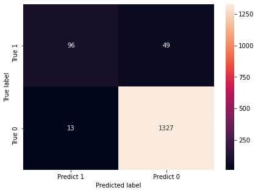

```
Trainig accuracy 0.9572624891712388

Testing accuracy 0.9582491582491582

Recall: 0.6620689655172414

Precision: 0.8807339449541285

F1 Score: 0.7559055118110236

Roc Auc Score: 0.8261837364899639
```

```python
model = LogisticRegression( solver='liblinear',penalty='l1')
model.fit(X_train, Y_train)

Y_predict = model.predict(X_test)

print('Confusion Matrix')
cm=metrics.confusion_matrix(Y_test, Y_predict, labels=[1, 0])

df_cm = pd.DataFrame(cm, index = [i for i in ["True 1","True 0"]],
                  columns = [i for i in ["Predict 1","Predict 0"]])

plt.figure(figsize = (7,5))
sns.heatmap(df_cm, annot=True,fmt='.0f')
plt.ylabel('True label')
plt.xlabel('Predicted label')
plt.show()

print("Trainig accuracy",model.score(X_train,Y_train))
print()
print("Testing accuracy",model.score(X_test, Y_test))
print()
print("Recall:",recall_score(Y_test,Y_predict))
print()
print("Precision:",precision_score(Y_test,Y_predict))
print()
print("F1 Score:",f1_score(Y_test,Y_predict))
print()
print("Roc Auc Score:",roc_auc_score(Y_test,Y_predict))
```

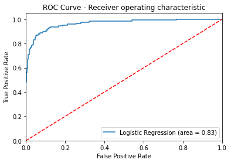

```python
#AUC ROC curve Analysis
logit_roc_auc = roc_auc_score(Y_test, model.predict(X_test))
fpr, tpr, thresholds = roc_curve(Y_test, model.predict_proba(X_test)[:,1])
plt.figure()
plt.plot(fpr, tpr, label='Logistic Regression (area = %0.2f)' % logit_roc_auc)
plt.plot([0, 1], [0, 1],'r--')
plt.xlim([0.0, 1.0])
plt.ylim([0.0, 1.05])
plt.xlabel('False Positive Rate')
plt.ylabel('True Positive Rate')
plt.title('ROC Curve - Receiver operating characteristic')
plt.legend(loc="lower right")
plt.show()
```

```python
print(model.get_params())
```

```
{'C': 1.0, 'class_weight': None, 'dual': False, 'fit_intercept': True, 'intercept_scaling': 1, 'l1_ratio': None, 'max_iter': 100, 'multi_class': 'warn', 'n_jobs': None, 'penalty': 'l1', 'random_state': None, 'solver': 'liblinear', 'tol': 0.0001, 'verbose': 0, 'warm_start': False}
```

```python
#Build the logistic regression model
logit = sm.Logit(Y_train, sm.add_constant(X_train))
lg = logit.fit()
```

```
Optimization terminated successfully.
         Current function value: 0.118484
         Iterations 9
```

```python
stats.chisqprob = lambda chisq, df: stats.chi2.sf(chisq, df)
print(lg.summary())
```

```
                           Logit Regression Results
==============================================================================
Dep. Variable:          Personal Loan   No. Observations:                 3463
Model:                          Logit   Df Residuals:                     3448
Method:                           MLE   Df Model:                           14
Date:                Thu, 09 Jul 2020   Pseudo R-squ.:                  0.6272
Time:                        01:06:37   Log-Likelihood:                -410.31
converged:                       True   LL-Null:                       -1100.7
Covariance Type:            nonrobust   LLR p-value:                2.173e-286
===================================================================================================
                                      coef    std err          z      P>|z|      [0.025      0.975]
---------------------------------------------------------------------------------------------------
const                              -9.7766      5.171     -1.891      0.059     -19.912       0.359
ID                              -3.862e-05   6.53e-05     -0.592      0.554      -0.000    8.93e-05
Age                                -0.0521      0.081     -0.640      0.522      -0.212       0.107
Experience                          0.0622      0.081      0.767      0.443      -0.097       0.221
Income                              0.0587      0.004     16.505      0.000       0.052       0.066
ZIP Code                        -1.869e-05   5.06e-05     -0.370      0.712      -0.000    8.04e-05
Family                              0.5800      0.092      6.272      0.000       0.399       0.761
CCAvg                               0.1726      0.053      3.237      0.001       0.068       0.277
Mortgage                            0.0011      0.001      1.561      0.118      -0.000       0.002
Education_Advanced/Professional     3.8958      0.315     12.348      0.000       3.277       4.514
Education_Graduate                  3.8396      0.316     12.133      0.000       3.219       4.460
Securities Account_Yes             -0.7910      0.362     -2.184      0.029      -1.501      -0.081
CD Account_Yes                      3.8874      0.419      9.279      0.000       3.066       4.708
Online_Yes                         -0.7355      0.197     -3.727      0.000      -1.122      -0.349
CreditCard_Yes                     -1.1639      0.260     -4.471      0.000      -1.674      -0.654
===================================================================================================

Possibly complete quasi-separation: A fraction 0.10 of observations can be
perfectly predicted. This might indicate that there is complete
quasi-separation. In this case some parameters will not be identified.
```

```python
# FIlter by significant p-value (pval <0.1) and sort descending by Odds ratio
lgcoef = pd.DataFrame(lg.params, columns=['coef'])
lgcoef.loc[:, "Odds_ratio"] = np.exp(lgcoef.coef)
lgcoef['probability'] = lgcoef['Odds_ratio']/(1+lgcoef['Odds_ratio'])
lgcoef['pval']=lg.pvalues
pd.options.display.float_format = '{:.2f}'.format
lgcoef = lgcoef.sort_values(by="Odds_ratio", ascending=False)
print("")
print("Good coefs - Pvalue <= 0.1 ")
print("")
pval_filter = lgcoef['pval']<=0.1
print(lgcoef[pval_filter])
print("")
print("Bad coefs - Pvalue > 0.1 ")
print("")
pval_filter2 = lgcoef['pval']>.1
print(lgcoef[pval_filter2])
```

```
Good coefs - Pvalue <= 0.1

                                 coef  Odds_ratio  probability  pval
Education_Advanced/Professional  3.90       49.20         0.98  0.00
CD Account_Yes                   3.89       48.78         0.98  0.00
Education_Graduate               3.84       46.51         0.98  0.00
Family                           0.58        1.79         0.64  0.00
CCAvg                            0.17        1.19         0.54  0.00
Income                           0.06        1.06         0.51  0.00
Online_Yes                      -0.74        0.48         0.32  0.00
Securities Account_Yes          -0.79        0.45         0.31  0.03
CreditCard_Yes                  -1.16        0.31         0.24  0.00
const                           -9.78        0.00         0.00  0.06

Bad coefs - Pvalue > 0.1

            coef  Odds_ratio  probability  pval
Experience  0.06        1.06         0.52  0.44
Mortgage    0.00        1.00         0.50  0.12
ZIP Code   -0.00        1.00         0.50  0.71
ID         -0.00        1.00         0.50  0.55
Age        -0.05        0.95         0.49  0.52
```

##### New database and modeling using only the main variables with pval < 0.1

```python
#Remove dependent variable and unwanted information and >0.1 p value variables

X2 = bank_model.drop(['Experience','Mortgage','ZIP Code','ID','Age','Personal Loan'], axis=1)
Y2 = bank_model['Personal Loan']
```

```python
# Split X and y into training and test set in 70:30 ratio

X2_train, X2_test, Y2_train, Y2_test = train_test_split(X2, Y2, test_size=0.30, random_state=1)
```

```python
print("\nCHECK Datasets size")
print("dataset:", len(bank_model),"rows")
print("X_train:", len(X2_train),"rows")
print("X_test: ", len(X2_test),"rows")
print("Y_train:", len(Y2_train),"rows")
print("Y_test: ", len(Y2_test),"rows")

print("\nCheck 70/30 Ratio")
print( "X train is:" ,round(len(X2_train) / (len(X2_train)+len(X2_test))*100,1),"% of total dataset")
print( "X test  is:" ,round(len(X2_test) / (len(X2_train)+len(X2_test))*100,1),"% of total dataset")
print( "Y train is:" ,round(len(Y2_train) / (len(Y2_train)+len(Y2_test))*100,1),"% of total dataset")
print( "Y test  is:" ,round(len(Y2_test) / (len(Y2_train)+len(Y2_test))*100,1),"% of total dataset")

print("\nCheck shapes")
print("dataset:", (bank_model.shape))
print("X_train:", (X2_train.shape))
print("X_test: ", (X2_test.shape))
print("Y_train:", (Y2_train.shape))
print("Y_test: ", (Y2_test.shape))
```

```
CHECK Datasets size
dataset: 4948 rows
X_train: 3463 rows
X_test:  1485 rows
Y_train: 3463 rows
Y_test:  1485 rows

Check 70/30 Ratio
X train is: 70.0 % of total dataset
X test  is: 30.0 % of total dataset
Y train is: 70.0 % of total dataset
Y test  is: 30.0 % of total dataset

Check shapes
dataset: (4948, 20)
X_train: (3463, 14)
X_test:  (1485, 14)
Y_train: (3463,)
Y_test:  (1485,)
```

```python
# Fit the model on train using sklearn with most important variables
model2 = LogisticRegression(random_state=42,penalty='l1', C = 0.75, solver="liblinear",class_weight='balanced')
model2.fit(X2_train, Y2_train)
#predict on test
Y2_predict = model2.predict(X2_test)

coef_df = pd.DataFrame(model2.coef_)
coef_df['intercept'] = model2.intercept_
print(coef_df)
```

```
     0    1    2    3     4     5    6     7     8    9   10    11   12    13  \
0 0.05 0.50 0.23 0.00 -0.01 -2.52 0.00 -0.95 -3.98 0.00 0.00 -0.79 0.00 -1.14

   intercept
0      -2.38
```

```
Confusion Matrix
```

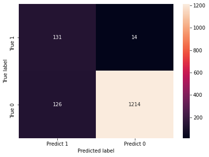

```
Trainig accuracy 0.9015304649148137

Testing accuracy 0.9057239057239057

Recall: 0.903448275862069

Precision: 0.5097276264591439

F1 Score: 0.6517412935323383

Roc Auc Score: 0.9047092125579002
```

```python
print('Confusion Matrix')
cm2=metrics.confusion_matrix(Y2_test, Y2_predict, labels=[1, 0])

df_cm2 = pd.DataFrame(cm2, index = [i for i in ["True 1","True 0"]],
                  columns = [i for i in ["Predict 1","Predict 0"]])

plt.figure(figsize = (7,5))
sns.heatmap(df_cm2, annot=True,fmt='.0f')
plt.ylabel('True label')
plt.xlabel('Predicted label')
plt.show()
print("Trainig accuracy",model2.score(X2_train,Y2_train))
print()
print("Testing accuracy",model2.score(X2_test, Y2_test))
print()
print("Recall:",recall_score(Y2_test,Y2_predict))
print()
print("Precision:",precision_score(Y2_test,Y2_predict))
print()
print("F1 Score:",f1_score(Y2_test,Y2_predict))
print()
print("Roc Auc Score:",roc_auc_score(Y2_test,Y2_predict))
```

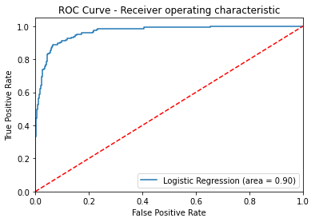

```python
#AUC ROC curve Analysis
logit_roc_auc = roc_auc_score(Y2_test, model2.predict(X2_test))
fpr, tpr, thresholds = roc_curve(Y2_test, model2.predict_proba(X2_test)[:,1])
plt.figure()
plt.plot(fpr, tpr, label='Logistic Regression (area = %0.2f)' % logit_roc_auc)
plt.plot([0, 1], [0, 1],'r--')
plt.xlim([0.0, 1.0])
plt.ylim([0.0, 1.05])
plt.xlabel('False Positive Rate')
plt.ylabel('True Positive Rate')
plt.title('ROC Curve - Receiver operating characteristic')
plt.legend(loc="lower right")
plt.show()
```

5) - Give your reasoning on how can the model perform better?

This model would perform better if information could be obtained for more customers.

With lower positives cases for study, models can have wrong results on production systems.

```python
print("COMPARISON OF MODEL 1 AND MODEL 2")
print()
print("MODEL 2 - LOWER PRECISION, BUT UPPER RECAL")
print("MODEL 1 - HIGHER PRECISION, BuT LOWER RECALL")
print()
print("Trainig accuracy 2",model2.score(X2_train,Y2_train))
print("Trainig accuracy 1",model.score(X_train,Y_train))
print()
print("Testing accuracy 2",model2.score(X2_test, Y2_test))
print("Testing accuracy 1",model.score(X_test, Y_test))
print()
print("Recall 2:",recall_score(Y2_test,Y2_predict))
print("Recall 1:",recall_score(Y_test,Y_predict))
print()
print("Precision 2:",precision_score(Y2_test,Y2_predict))
print("Precision 1:",precision_score(Y_test,Y_predict))
print()
print("F1 Score 2:",f1_score(Y2_test,Y2_predict))
print("F1 Score 1:",f1_score(Y_test,Y_predict))
print()
print("Roc Auc Score 2:",roc_auc_score(Y2_test,Y2_predict))
print("Roc Auc Score 1:",roc_auc_score(Y_test,Y_predict))
```

```
COMPARISON OF MODEL 1 AND MODEL 2

MODEL 2 - LOWER PRECISION, BUT UPPER RECAL
MODEL 1 - HIGHER PRECISION, BuT LOWER RECALL

Trainig accuracy 2 0.9015304649148137
Trainig accuracy 1 0.9572624891712388

Testing accuracy 2 0.9057239057239057
Testing accuracy 1 0.9582491582491582

Recall 2: 0.903448275862069
Recall 1: 0.6620689655172414

Precision 2: 0.5097276264591439
Precision 1: 0.8807339449541285

F1 Score 2: 0.6517412935323383
F1 Score 1: 0.7559055118110236

Roc Auc Score 2: 0.9047092125579002
Roc Auc Score 1: 0.8261837364899639
```

6) - Give Business understanding of your model?

It is created 2 models for different segments of use:

first model is more accurated, with high precision, byt for lower number of customers.

second model is more populous, with lower precision, but for more customers on possibility to achieve a personal loan.

its recomended to use the second model on marketing actions, as we can try to get more loans vollume. its recomended to use the fisrt model if its need to more accuracy, as a credit and fraud model/filter.

The results of the model, on a businness view is:

Positive (1) = there is a positive trend of customer get a personal loan Negative (0) = there is a negative trend of customer get a personal loan

The variables that define the trend with logistic regression are:

```
- 'Income',
- 'Family',
- 'CCAvg',
- 'Education',
- 'Securities Account',
- 'CD Account',
- 'Online',
- 'CreditCard'.
```